# VKR_2

**Построение модели машинного обучения для прогноза модуля упругости при растяжении и модели машинного обучения для прогноза прочности при растяжении**

Импортируем необходимые библиотеки

```python
import pandas as pd
import numpy as np
import matplotlib.pyplot as plt
import seaborn as sns
from sklearn.model_selection import train_test_split

from sklearn.linear_model import LinearRegression
from sklearn.neighbors import KNeighborsRegressor
from sklearn.ensemble import RandomForestRegressor
from sklearn.linear_model import BayesianRidge
from sklearn.linear_model import Lasso
from sklearn.model_selection import GridSearchCV
from sklearn import metrics
from sklearn.preprocessing import MinMaxScaler

import warnings
warnings.filterwarnings("ignore")
```

Загружаем итоговый датасет

```python
df = pd.read_excel('db_itog_bez_norm.xlsx')
```

```python
df.drop('Unnamed: 0', axis=1,inplace=True)
df.head()
```

|  | Соотношение матрица-наполнитель | Плотность, кг/м3 | модуль упругости, ГПа | Количество отвердителя, м.% | Поверхностная плотность, г/м2 | Модуль упругости при растяжении, ГПа | Прочность при растяжении, МПа | Шаг нашивки | Плотность нашивки | Угол нашивки, град_0 | Угол нашивки, град_90 | Содержание эпоксидных групп, г | Потребление смолы, г/м2 без ЭГ |
| --- | --- | --- | --- | --- | --- | --- | --- | --- | --- | --- | --- | --- | --- |
| 0 | 1.857143 | 2030.0 | 738.736842 | 50.00 | 210.0 | 70.0 | 3000.0 | 4.0 | 60.0 | 1 | 0 | 52.250000 | 167.750000 |
| 1 | 1.857143 | 2030.0 | 738.736842 | 49.90 | 210.0 | 70.0 | 3000.0 | 4.0 | 70.0 | 1 | 0 | 72.600000 | 147.400000 |
| 2 | 1.857143 | 2030.0 | 738.736842 | 129.00 | 210.0 | 70.0 | 3000.0 | 5.0 | 47.0 | 1 | 0 | 46.750000 | 173.250000 |
| 3 | 2.771331 | 2030.0 | 753.000000 | 111.86 | 210.0 | 70.0 | 3000.0 | 5.0 | 57.0 | 1 | 0 | 48.989286 | 171.010714 |
| 4 | 2.767918 | 2000.0 | 748.000000 | 111.86 | 210.0 | 70.0 | 3000.0 | 5.0 | 60.0 | 1 | 0 | 48.989286 | 171.010714 |

Подготавливаем датафреймы для создания обучающей и тестовой выборки, а именно исключаем и выносим в отдельный датафрейм переменные в отношении которых необходимо подготовить прогнозирующую модель

```python
data_for_models = df.copy()
X_proch = df.drop("Прочность при растяжении, МПа", axis=1)
y_proch = df['Прочность при растяжении, МПа']

X_mod_uprug = df.drop("Модуль упругости при растяжении, ГПа", axis=1)
y_mod_uprug = df["Модуль упругости при растяжении, ГПа"]
```

Масштабирование данных

Масштабирование данных — это процесс преобразования числовых признаков в наборе данных к одному масштабу, чтобы они имели одинаковый диапазон значений. Это необходимо, потому что многие алгоритмы машинного обучения чувствительны к разным масштабам признаков, и масштабирование помогает избежать ситуации, когда один признак доминирует над другими. Масштабирование применяется для: Улучшение работы алгоритмов. Многие алгоритмы, особенно те, что основаны на расстоянии (например, KNN, K-means, SVM) или градиентном спуске, работают лучше, когда признаки имеют одинаковый масштаб. Предотвращение доминирования признаков. Если один признак имеет большой диапазон значений, а другой – маленький, то первый может оказывать большее влияние на модель, даже если его важность не выше. Масштабирование выравнивает вклад каждого признака. Оптимизация обучения. Масштабирование может ускорить процесс обучения модели и повысить ее точность.

Нормализация (Max-Min Normalization, Min-Max Scaling) – техника преобразования значений признака, масштабирующая значения таким образом, что они располагаются в диапазоне от 0 до 1. Цель такого преобразования – изменить значения числовых столбцов в наборе данных так, чтобы сохранить различия их диапазонов. В Машинном обучении датасет требует нормализации, когда признаки имеют разные диапазоны и тем самым способствуют искажению восприятия взаимоотношений между Переменными-предикторами (Predictor Variable) и Целевой переменной (Target Variable).

Принимаем решения о нормализации данных. Используем MinMaxScaler из модуля sklearn.

Нормализуем данные дата фрейма X_proch с помощью MinMaxScaler()

```python
mms_proch = MinMaxScaler()
col = X_proch.columns
result = mms_proch.fit_transform(X_proch)

X_proch = pd.DataFrame(result, columns = col)
X_proch.describe()
```

|  | Соотношение матрица-наполнитель | Плотность, кг/м3 | модуль упругости, ГПа | Количество отвердителя, м.% | Поверхностная плотность, г/м2 | Модуль упругости при растяжении, ГПа | Шаг нашивки | Плотность нашивки | Угол нашивки, град_0 | Угол нашивки, град_90 | Содержание эпоксидных групп, г | Потребление смолы, г/м2 без ЭГ |
| --- | --- | --- | --- | --- | --- | --- | --- | --- | --- | --- | --- | --- |
| count | 925.000000 | 925.000000 | 925.000000 | 925.000000 | 925.000000 | 925.000000 | 925.000000 | 925.000000 | 925.000000 | 925.000000 | 925.000000 | 925.000000 |
| mean | 0.497546 | 0.503436 | 0.450854 | 0.505851 | 0.374074 | 0.487438 | 0.502436 | 0.504042 | 0.486486 | 0.513514 | 0.486999 | 0.505240 |
| std | 0.188196 | 0.188667 | 0.201595 | 0.187418 | 0.216236 | 0.195421 | 0.183617 | 0.192942 | 0.500088 | 0.500088 | 0.190326 | 0.190173 |
| min | 0.000000 | 0.000000 | 0.000000 | 0.000000 | 0.000000 | 0.000000 | 0.000000 | 0.000000 | 0.000000 | 0.000000 | 0.000000 | 0.000000 |
| 25% | 0.370724 | 0.368017 | 0.305176 | 0.378362 | 0.206500 | 0.355991 | 0.370933 | 0.376961 | 0.000000 | 0.000000 | 0.347856 | 0.380455 |
| 50% | 0.494224 | 0.511348 | 0.452951 | 0.506352 | 0.356477 | 0.484115 | 0.504549 | 0.504853 | 0.000000 | 1.000000 | 0.486436 | 0.504801 |
| 75% | 0.629154 | 0.626775 | 0.586757 | 0.639114 | 0.537667 | 0.617537 | 0.625697 | 0.631086 | 1.000000 | 1.000000 | 0.615519 | 0.637710 |
| max | 1.000000 | 1.000000 | 1.000000 | 1.000000 | 1.000000 | 1.000000 | 1.000000 | 1.000000 | 1.000000 | 1.000000 | 1.000000 | 1.000000 |

```python
y_proch.describe()
```

```
count     925.000000
mean     2460.116851
std       450.916069
min      1250.392802
25%      2149.974687
50%      2456.395009
75%      2751.235671
max      3636.892992
Name: Прочность при растяжении, МПа, dtype: float64
```

Нормализуем данные дата фрейма X_mod_uprug с помощью MinMaxScaler()

```python
mms_mod_uprug = MinMaxScaler()
col = X_mod_uprug.columns
result = mms_mod_uprug.fit_transform(X_mod_uprug)

X_mod_uprug = pd.DataFrame(result, columns = col)
X_mod_uprug.describe()
```

|  | Соотношение матрица-наполнитель | Плотность, кг/м3 | модуль упругости, ГПа | Количество отвердителя, м.% | Поверхностная плотность, г/м2 | Прочность при растяжении, МПа | Шаг нашивки | Плотность нашивки | Угол нашивки, град_0 | Угол нашивки, град_90 | Содержание эпоксидных групп, г | Потребление смолы, г/м2 без ЭГ |
| --- | --- | --- | --- | --- | --- | --- | --- | --- | --- | --- | --- | --- |
| count | 925.000000 | 925.000000 | 925.000000 | 925.000000 | 925.000000 | 925.000000 | 925.000000 | 925.000000 | 925.000000 | 925.000000 | 925.000000 | 925.000000 |
| mean | 0.497546 | 0.503436 | 0.450854 | 0.505851 | 0.374074 | 0.506903 | 0.502436 | 0.504042 | 0.486486 | 0.513514 | 0.486999 | 0.505240 |
| std | 0.188196 | 0.188667 | 0.201595 | 0.187418 | 0.216236 | 0.188944 | 0.183617 | 0.192942 | 0.500088 | 0.500088 | 0.190326 | 0.190173 |
| min | 0.000000 | 0.000000 | 0.000000 | 0.000000 | 0.000000 | 0.000000 | 0.000000 | 0.000000 | 0.000000 | 0.000000 | 0.000000 | 0.000000 |
| 25% | 0.370724 | 0.368017 | 0.305176 | 0.378362 | 0.206500 | 0.376946 | 0.370933 | 0.376961 | 0.000000 | 0.000000 | 0.347856 | 0.380455 |
| 50% | 0.494224 | 0.511348 | 0.452951 | 0.506352 | 0.356477 | 0.505343 | 0.504549 | 0.504853 | 0.000000 | 1.000000 | 0.486436 | 0.504801 |
| 75% | 0.629154 | 0.626775 | 0.586757 | 0.639114 | 0.537667 | 0.628889 | 0.625697 | 0.631086 | 1.000000 | 1.000000 | 0.615519 | 0.637710 |
| max | 1.000000 | 1.000000 | 1.000000 | 1.000000 | 1.000000 | 1.000000 | 1.000000 | 1.000000 | 1.000000 | 1.000000 | 1.000000 | 1.000000 |

```python
y_mod_uprug.describe()
```

```
count    925.000000
mean      73.304924
std        3.011295
min       65.793845
25%       71.279418
50%       73.253725
75%       75.309657
max       81.203147
Name: Модуль упругости при растяжении, ГПа, dtype: float64
```

Создание обучающей и тестирующей выборки для прогноза по переменной "Прочность при растяжении, МПа". Разделение по принципу 70% данных относится к обучающей выборки и 30% относится к тестирующей выборки.

```python
X_train_proch, X_test_proch, y_train_proch, y_test_proch = train_test_split(X_proch, y_proch, test_size=0.3, random_state=0, shuffle=True)
```

Проверям что обучающая и тестирующая выборки для прогноза по переменной "Прочность при растяжении, МПа" созданы корректно.

```python
X_train_proch.head()
```

|  | Соотношение матрица-наполнитель | Плотность, кг/м3 | модуль упругости, ГПа | Количество отвердителя, м.% | Поверхностная плотность, г/м2 | Модуль упругости при растяжении, ГПа | Шаг нашивки | Плотность нашивки | Угол нашивки, град_0 | Угол нашивки, град_90 | Содержание эпоксидных групп, г | Потребление смолы, г/м2 без ЭГ |
| --- | --- | --- | --- | --- | --- | --- | --- | --- | --- | --- | --- | --- |
| 48 | 0.158102 | 0.725190 | 0.576675 | 0.682142 | 0.405384 | 0.232913 | 0.446045 | 0.726996 | 1.0 | 0.0 | 0.529288 | 0.502252 |
| 306 | 0.619850 | 0.769181 | 0.263654 | 0.501200 | 0.541645 | 0.473322 | 0.160618 | 0.379040 | 1.0 | 0.0 | 0.517291 | 0.468870 |
| 263 | 0.532021 | 0.559514 | 0.443638 | 0.559515 | 0.129828 | 0.547563 | 0.229111 | 0.191757 | 1.0 | 0.0 | 0.359648 | 0.240430 |
| 749 | 0.722379 | 0.619887 | 0.435784 | 0.441711 | 0.542370 | 0.503371 | 0.755744 | 0.420222 | 0.0 | 1.0 | 0.522485 | 0.588697 |
| 648 | 0.376244 | 0.491648 | 0.146501 | 0.259451 | 0.545220 | 0.588516 | 0.502273 | 0.224795 | 0.0 | 1.0 | 0.601278 | 0.583609 |

```python
X_train_proch.shape
```

```
(647, 12)
```

```python
X_test_proch.head()
```

|  | Соотношение матрица-наполнитель | Плотность, кг/м3 | модуль упругости, ГПа | Количество отвердителя, м.% | Поверхностная плотность, г/м2 | Модуль упругости при растяжении, ГПа | Шаг нашивки | Плотность нашивки | Угол нашивки, град_0 | Угол нашивки, град_90 | Содержание эпоксидных групп, г | Потребление смолы, г/м2 без ЭГ |
| --- | --- | --- | --- | --- | --- | --- | --- | --- | --- | --- | --- | --- |
| 308 | 0.330840 | 0.493907 | 0.334887 | 0.901624 | 0.271493 | 0.561482 | 0.354639 | 0.236418 | 1.0 | 0.0 | 0.541704 | 0.655402 |
| 352 | 0.520203 | 0.825374 | 0.564928 | 0.468778 | 0.665379 | 0.430624 | 0.328661 | 0.608536 | 1.0 | 0.0 | 0.378438 | 0.450856 |
| 665 | 0.571982 | 0.487762 | 0.569393 | 0.462942 | 0.262282 | 0.587542 | 0.514526 | 0.421655 | 0.0 | 1.0 | 0.721889 | 0.714210 |
| 909 | 0.301038 | 0.491187 | 0.328963 | 0.472701 | 0.208149 | 0.570038 | 0.176512 | 0.251281 | 0.0 | 1.0 | 0.875925 | 0.752797 |
| 812 | 0.871067 | 0.470143 | 0.086004 | 0.748675 | 0.472314 | 0.444866 | 0.202120 | 0.438186 | 0.0 | 1.0 | 0.396252 | 0.423092 |

```python
X_test_proch.shape
```

```
(278, 12)
```

```python
y_train_proch.head()
```

```
48     2561.544646
306    3141.616040
263    2370.338363
749    2647.588058
648    2646.858411
Name: Прочность при растяжении, МПа, dtype: float64
```

```python
y_train_proch.shape
```

```
(647,)
```

```python
y_test_proch.head()
```

```
308    2723.281123
352    2844.655510
665    2648.655464
909    2322.432527
812    2253.684145
Name: Прочность при растяжении, МПа, dtype: float64
```

```python
y_test_proch.shape
```

```
(278,)
```

Создание обучающей и тестирующей выборки для прогноза по переменной "Модуль упругости при растяжении, ГПа". Разделение по принципу 70% данных относится к обучающей выборки и 30% относится к тестирующей выборки.

```python
X_train_mod_uprug, X_test_mod_uprug, y_train_mod_uprug, y_test_mod_uprug = train_test_split(X_mod_uprug, y_mod_uprug, test_size=0.3, random_state=0, shuffle=True)
```

Проверяем что обучающие и тестовые выборки дял прогноза по переменной "Модуль упругости при растяжении, ГПа" созданны корректно.

```python
X_train_mod_uprug.head()
```

|  | Соотношение матрица-наполнитель | Плотность, кг/м3 | модуль упругости, ГПа | Количество отвердителя, м.% | Поверхностная плотность, г/м2 | Прочность при растяжении, МПа | Шаг нашивки | Плотность нашивки | Угол нашивки, град_0 | Угол нашивки, град_90 | Содержание эпоксидных групп, г | Потребление смолы, г/м2 без ЭГ |
| --- | --- | --- | --- | --- | --- | --- | --- | --- | --- | --- | --- | --- |
| 48 | 0.158102 | 0.725190 | 0.576675 | 0.682142 | 0.405384 | 0.549404 | 0.446045 | 0.726996 | 1.0 | 0.0 | 0.529288 | 0.502252 |
| 306 | 0.619850 | 0.769181 | 0.263654 | 0.501200 | 0.541645 | 0.792467 | 0.160618 | 0.379040 | 1.0 | 0.0 | 0.517291 | 0.468870 |
| 263 | 0.532021 | 0.559514 | 0.443638 | 0.559515 | 0.129828 | 0.469284 | 0.229111 | 0.191757 | 1.0 | 0.0 | 0.359648 | 0.240430 |
| 749 | 0.722379 | 0.619887 | 0.435784 | 0.441711 | 0.542370 | 0.585458 | 0.755744 | 0.420222 | 0.0 | 1.0 | 0.522485 | 0.588697 |
| 648 | 0.376244 | 0.491648 | 0.146501 | 0.259451 | 0.545220 | 0.585152 | 0.502273 | 0.224795 | 0.0 | 1.0 | 0.601278 | 0.583609 |

```python
X_train_mod_uprug.shape
```

```
(647, 12)
```

```python
X_test_mod_uprug.head()
```

|  | Соотношение матрица-наполнитель | Плотность, кг/м3 | модуль упругости, ГПа | Количество отвердителя, м.% | Поверхностная плотность, г/м2 | Прочность при растяжении, МПа | Шаг нашивки | Плотность нашивки | Угол нашивки, град_0 | Угол нашивки, град_90 | Содержание эпоксидных групп, г | Потребление смолы, г/м2 без ЭГ |
| --- | --- | --- | --- | --- | --- | --- | --- | --- | --- | --- | --- | --- |
| 308 | 0.330840 | 0.493907 | 0.334887 | 0.901624 | 0.271493 | 0.617175 | 0.354639 | 0.236418 | 1.0 | 0.0 | 0.541704 | 0.655402 |
| 352 | 0.520203 | 0.825374 | 0.564928 | 0.468778 | 0.665379 | 0.668034 | 0.328661 | 0.608536 | 1.0 | 0.0 | 0.378438 | 0.450856 |
| 665 | 0.571982 | 0.487762 | 0.569393 | 0.462942 | 0.262282 | 0.585905 | 0.514526 | 0.421655 | 0.0 | 1.0 | 0.721889 | 0.714210 |
| 909 | 0.301038 | 0.491187 | 0.328963 | 0.472701 | 0.208149 | 0.449210 | 0.176512 | 0.251281 | 0.0 | 1.0 | 0.875925 | 0.752797 |
| 812 | 0.871067 | 0.470143 | 0.086004 | 0.748675 | 0.472314 | 0.420403 | 0.202120 | 0.438186 | 0.0 | 1.0 | 0.396252 | 0.423092 |

```python
X_test_mod_uprug.shape
```

```
(278, 12)
```

```python
y_train_mod_uprug.head()
```

```
48     69.382866
306    73.087407
263    74.231408
749    73.550433
648    74.862468
Name: Модуль упругости при растяжении, ГПа, dtype: float64
```

```python
y_train_mod_uprug.shape
```

```
(647,)
```

```python
y_test_mod_uprug.head()
```

```
308    74.445891
352    72.429467
665    74.847458
909    74.577734
812    72.648916
Name: Модуль упругости при растяжении, ГПа, dtype: float64
```

```python
y_test_mod_uprug.shape
```

```
(278,)
```

**Метрики**

Метрики в машинном обучении – это количественные показатели, используемые для оценки производительности моделей. Они позволяют оценить, насколько хорошо модель выполняет поставленную задачу, будь то классификация, регрессия или другие типы задач. Выбор правильной метрики критически важен для оценки и сравнения различных моделей, а также для оптимизации их работы.

При оценке моделей будем использовать следующие метрики:

1. Корень средней квадратичной ошибки (RMSE) является одним из двух основных показателей эффективности для моделей прогнозирования регрессии. Это исследование устанавливает среднюю разницу между значениями, спрогнозированными моделями прогнозирования и фактическими значениями. Он дает оценку того, что хорошая модель может предсказать целевое значение (оценку точности).
2. MAE, или Mean Absolute Error (Средняя абсолютная ошибка), это метрика, которая используется для оценки точности моделей машинного обучения, в частности, регрессионных моделей. Она показывает среднее значение абсолютных разностей между прогнозируемыми и фактическими значениями. Чем меньше значение MAE, тем лучше модель предсказывает данные.
3. R2 - Статистический показатель, отражающий объясняющую способность регрессии f: X→Y и определяемый как доля дисперсии зависимой переменной, объясненная регрессионной моделью с данным набором независимых переменных. Коэффициент детерминации изменяется в диапазоне от − ∞ до 1. Если он равен 1, это соответствует идеальной модели, когда все точки наблюдений лежат точно на линии регрессии, т.е. сумма квадратов их отклонений равна 0. Если коэффициент детерминации равен 0, это означает, что связь между переменными регрессионной модели отсутствует, и вместо нее для оценки значения выходной переменной можно использовать простое среднее ее наблюдаемых значений.
4. MAPE, или средняя абсолютная процентная ошибка (Mean Absolute Percentage Error), это метрика, используемая для оценки точности моделей прогнозирования. Она показывает среднее значение абсолютной процентной разницы между фактическими и прогнозируемыми значениями. Другими словами, MAPE измеряет, насколько в среднем прогнозы отличаются от реальных значений в процентах.

**Построение модели на основе Линейной регрессии (LinearRegression)**

Линейная регрессия - это метод статистического анализа, который используется для моделирования взаимосвязи между зависимой переменной и одной или несколькими независимыми переменными путем подбора линейного уравнения. Проще говоря, она позволяет предсказать значения зависимой переменной, основываясь на значениях независимых переменных.

Построение и тестирование модели Линейной регрессии (LinearRegression) для предсказания переменной "Прочность при растяжении, МПа"

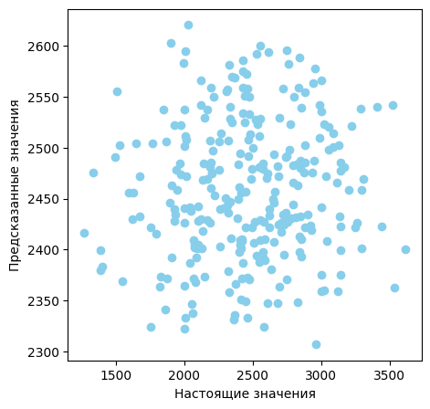

```
Корень из среднеквадратичной ошибки: 451.34204146327596
MAE: 365.02993743964964
R2 -0.003964508608367945
MAPE: 0.15986495520338406
Коэффициенты регрессии: [   3.71788611 -286.22167735   -7.51855558  -91.27900555   -8.27752849
  -76.00292956 -190.5991545    53.25922147    2.33782713   -2.33782713
   15.19405669  -27.37189604]
Константа: 2766.9711967652634
```

```python
# При построении модели пользуемся библиотекой sklearn.linear_model
regressor = LinearRegression()
regressor.fit(X_train_proch, y_train_proch)
y_pred_proch = regressor.predict(X_test_proch)


# Визуализируем на диаграмме рассеяния соотношение предсказанных и настоящих значений
plt.figure(figsize=(5, 5))
plt.scatter(y_test_proch, y_pred_proch, color="skyblue")
plt.xlabel("Настоящие значения")
plt.ylabel("Предсказанные значения")
plt.show()

# Выводим значения метрик
print("Корень из среднеквадратичной ошибки:", np.sqrt(metrics.mean_squared_error(y_test_proch, y_pred_proch)))
print("MAE:", metrics.mean_absolute_error(y_test_proch, y_pred_proch))
print("R2", metrics.r2_score(y_test_proch, y_pred_proch))
print("MAPE:", metrics.mean_absolute_percentage_error(y_test_proch, y_pred_proch))
print("Коэффициенты регрессии:", regressor.coef_)
print("Константа:", regressor.intercept_)

# Создаем датафрейм в который занесем результаты тестирования каждой модели
# Данный датафрейм используем при итоговом сравнении моделей
data_sravn = [
    [np.sqrt(metrics.mean_squared_error(y_test_proch, y_pred_proch))],
    [metrics.mean_absolute_error(y_test_proch, y_pred_proch)],
    [metrics.r2_score(y_test_proch, y_pred_proch)],
    [metrics.mean_absolute_percentage_error(y_test_proch, y_pred_proch)],
]

metrics_index = ['RMSE','MAE','R2','MAPE']
df_sravnenie = pd.DataFrame(data=data_sravn, index=metrics_index)
df_sravnenie.rename(columns={0:'LinearRegression_proch'},inplace=True)
```

Построение и тестирование модели Линейной регрессии (LinearRegression) для предсказания переменной "Модуль упругости при растяжении, ГПа"

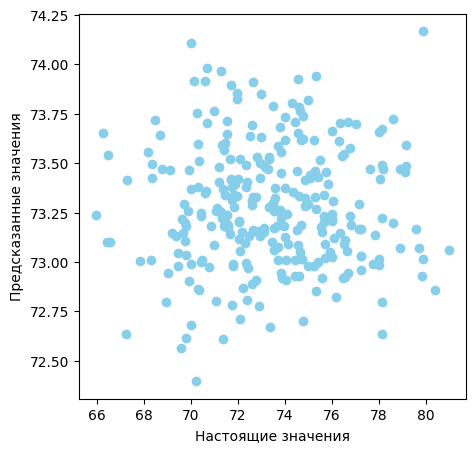

```
Корень из среднеквадратичной ошибки: 2.986900936096138
MAE: 2.421377839386351
R2 -0.01208198695063989
MAPE: 0.03298137627511868
Коэффициенты регрессии: [-0.58338399 -0.58997389 -0.17812112 -0.220153    0.1402872  -0.5368078
 -0.61777874  0.47785495 -0.0805161   0.0805161   1.70074587 -1.30625937]
Константа: 74.16702344988468
```

```python
# При построении модели пользуемся библиотекой sklearn.linear_model
regressor = LinearRegression()
regressor.fit(X_train_mod_uprug, y_train_mod_uprug)
y_pred_mod_uprug = regressor.predict(X_test_mod_uprug)

# Визуализируем на диаграмме рассеяния соотношение предсказанных и настоящих значений
plt.figure(figsize=(5, 5))
plt.scatter(y_test_mod_uprug, y_pred_mod_uprug, color="skyblue")
plt.xlabel("Настоящие значения")
plt.ylabel("Предсказанные значения")
plt.show()

# Выводим значения метрик
print("Корень из среднеквадратичной ошибки:", np.sqrt(metrics.mean_squared_error(y_test_mod_uprug, y_pred_mod_uprug)))
print("MAE:", metrics.mean_absolute_error(y_test_mod_uprug, y_pred_mod_uprug))
print("R2", metrics.r2_score(y_test_mod_uprug, y_pred_mod_uprug))
print("MAPE:", metrics.mean_absolute_percentage_error(y_test_mod_uprug, y_pred_mod_uprug))
print("Коэффициенты регрессии:", regressor.coef_)
print("Константа:", regressor.intercept_)

# Переносим полученные метрики в датафрейм, который будет использоваться при итоговом сравнении моделей
data_sravn = [
    [np.sqrt(metrics.mean_squared_error(y_test_mod_uprug, y_pred_mod_uprug))],
    [metrics.mean_absolute_error(y_test_mod_uprug, y_pred_mod_uprug)],
    [metrics.r2_score(y_test_mod_uprug, y_pred_mod_uprug)],
    [metrics.mean_absolute_percentage_error(y_test_mod_uprug, y_pred_mod_uprug)],
]

df_sravnenie['LinearRegression_uprug'] = np.array(data_sravn)
```

**Построение модели Регрессии на основе k-ближайших соседей (KNeighborsRegressor)**

К-ближайших соседей (K-Nearest Neighbors или просто KNN) — алгоритм классификации и регрессии, основанный на гипотезе компактности, которая предполагает, что расположенные близко друг к другу объекты в пространстве признаков имеют схожие значения целевой переменной или принадлежат к одному классу.

Построение и тестирование модели Регрессии на основе k-ближайших соседей (KNeighborsRegressor) для предсказания переменной "Прочность при растяжении, МПа"

```python
# при построении модели используем библиотеку sklearn
knn = KNeighborsRegressor()

knn.fit(X_train_proch, y_train_proch)
y_pred_proch = knn.predict(X_test_proch)
```

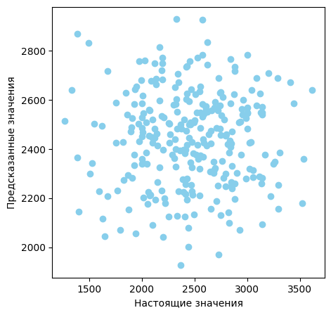

```
Корень из среднеквадратичной ошибки: 488.60301188371545
MAE: 392.86910688443356
R2 -0.1765734982566982
MAPE: 0.17042995789958992
```

```python
# Визуализируем на диаграмме рассеяния соотношение предсказанных и настоящих значений
plt.figure(figsize=(5, 5))
plt.scatter(y_test_proch, y_pred_proch, color='skyblue')
plt.xlabel("Настоящие значения")
plt.ylabel("Предсказанные значения")
plt.show()

# Выводим значения метрик
print("Корень из среднеквадратичной ошибки:", np.sqrt(metrics.mean_squared_error(y_test_proch, y_pred_proch)))
print("MAE:", metrics.mean_absolute_error(y_test_proch, y_pred_proch))
print("R2", metrics.r2_score(y_test_proch, y_pred_proch))
print("MAPE:", metrics.mean_absolute_percentage_error(y_test_proch, y_pred_proch))
```

Проведем поиск гиперпараметров модели с помощью поиска по сетке с перекрестной проверкой, количество блоков равно 10. Используем объект GridSearchCV из библиотеки sklearn, который поможет выбрать наилучшие параметры.

```python
# Подберём параметры используя GridSearchCV
n_neighbors = range(1, 50)
p = [1, 2]
weights = ["uniform", "distance"]
metric = ["mahalanobis", "minkowski", "cosine", "chebyshev", "correlation", "euclidean"]
algorithm = ["ball_tree", "kd_tree", "brute"]

hyperparameters = dict(n_neighbors=n_neighbors, weights=weights, p=p, metric=metric, algorithm=algorithm)
```

```python
knn = KNeighborsRegressor()
search = GridSearchCV(knn, hyperparameters, cv=10, verbose=1)
best_model = search.fit(X_train_proch, y_train_proch)
```

```
Fitting 10 folds for each of 3528 candidates, totalling 35280 fits
```

```python
best_model.best_estimator_
```

```
KNeighborsRegressor(algorithm='ball_tree', n_neighbors=48, p=1)
```

```python
knn = best_model.best_estimator_
knn.fit(X_train_proch, y_train_proch)
y_pred_proch = knn.predict(X_test_proch)

# Выводим значения метрик (после поиска гиперпараметров)
print("Корень из среднеквадратичной ошибки:",np.sqrt(metrics.mean_squared_error(y_test_proch, y_pred_proch)))
print("MAE:", metrics.mean_absolute_error(y_test_proch, y_pred_proch))
print("R2", metrics.r2_score(y_test_proch, y_pred_proch))
print("MAPE:", metrics.mean_absolute_percentage_error(y_test_proch, y_pred_proch))

# Переносим полученные метрики в датафрейм, который будет использоваться при итоговом сравнении моделей
data_sravn = [
    [np.sqrt(metrics.mean_squared_error(y_test_proch, y_pred_proch))],
    [metrics.mean_absolute_error(y_test_proch, y_pred_proch)],
    [metrics.r2_score(y_test_proch, y_pred_proch)],
    [metrics.mean_absolute_percentage_error(y_test_proch, y_pred_proch)],
]

df_sravnenie["KNR_GSCV_proch"] = np.array(data_sravn)
```

```
Корень из среднеквадратичной ошибки: 452.4531325358677
MAE: 365.86009954452174
R2 -0.00891361122238754
MAPE: 0.16084622619523814
```

Построение и тестирование модели Регрессии на основе k-ближайших соседей (KNeighborsRegressor) для предсказания переменной "Модуль упругости при растяжении, ГПа"

```python
# при построении модели используем библиотеку sklearn
knn = KNeighborsRegressor()

knn.fit(X_train_mod_uprug, y_train_mod_uprug)
y_pred_mod_uprug = knn.predict(X_test_mod_uprug)
```

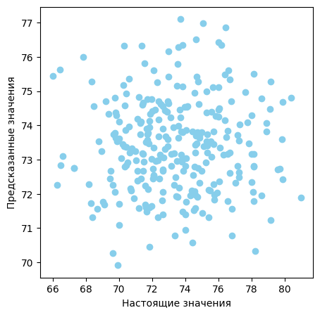

```
Корень из среднеквадратичной ошибки: 3.23140577094596
MAE: 2.603313484473943
R2 -0.18455996317736534
MAPE: 0.03549890556868933
```

```python
# Визуализируем на диаграмме рассеяния соотношение предсказанных и настоящих значений
plt.figure(figsize=(5, 5))
plt.scatter(y_test_mod_uprug, y_pred_mod_uprug, color="skyblue")
plt.xlabel("Настоящие значения")
plt.ylabel("Предсказанные значения")
plt.show()
# Выводим значения метрик
print("Корень из среднеквадратичной ошибки:", np.sqrt(metrics.mean_squared_error(y_test_mod_uprug, y_pred_mod_uprug)))
print("MAE:", metrics.mean_absolute_error(y_test_mod_uprug, y_pred_mod_uprug))
print("R2", metrics.r2_score(y_test_mod_uprug, y_pred_mod_uprug))
print("MAPE:", metrics.mean_absolute_percentage_error(y_test_mod_uprug, y_pred_mod_uprug))
```

Проведем поиск гиперпараметров модели с помощью поиска по сетке с перекрестной проверкой, количество блоков равно 10. Используем объект GridSearchCV из библиотеки sklearn, который поможет выбрать наилучшие параметры.

```python
# Подберём параметры используя GridSearchCV
n_neighbors = range(1, 50)
p = [1, 2]
weights = ["uniform", "distance"]
metric = ["mahalanobis", "minkowski", "cosine", "chebyshev", "correlation", "euclidean"]
algorithm = ["ball_tree", "kd_tree", "brute"]

hyperparameters = dict(n_neighbors=n_neighbors, weights=weights, p=p, metric=metric, algorithm=algorithm)
```

```python
knn = KNeighborsRegressor()
search = GridSearchCV(knn, hyperparameters, cv=10, verbose=1)
best_model = search.fit(X_train_mod_uprug, y_train_mod_uprug)
```

```
Fitting 10 folds for each of 3528 candidates, totalling 35280 fits
```

```python
best_model.best_estimator_
```

```
KNeighborsRegressor(algorithm='ball_tree', n_neighbors=33, p=1)
```

```python
knn = best_model.best_estimator_
knn.fit(X_train_mod_uprug, y_train_mod_uprug)
y_pred_mod_uprug = knn.predict(X_test_mod_uprug)

# Выводим значения метрик
print("Корень из среднеквадратичной ошибки:", np.sqrt(metrics.mean_squared_error(y_test_mod_uprug, y_pred_mod_uprug)))
print("MAE:", metrics.mean_absolute_error(y_test_mod_uprug, y_pred_mod_uprug))
print("R2", metrics.r2_score(y_test_mod_uprug, y_pred_mod_uprug))
print("MAPE:", metrics.mean_absolute_percentage_error(y_test_mod_uprug, y_pred_mod_uprug))

# Переносим полученные метрики в датафрейм, который будет использоваться при итоговом сравнении моделей
data_sravn = [
    [np.sqrt(metrics.mean_squared_error(y_test_mod_uprug, y_pred_mod_uprug))],
    [metrics.mean_absolute_error(y_test_mod_uprug, y_pred_mod_uprug)],
    [metrics.r2_score(y_test_mod_uprug, y_pred_mod_uprug)],
    [metrics.mean_absolute_percentage_error(y_test_mod_uprug, y_pred_mod_uprug)],
]

df_sravnenie["KNR_GSCV_upr"] = np.array(data_sravn)
```

```
Корень из среднеквадратичной ошибки: 2.9824205901887875
MAE: 2.4341991282788467
R2 -0.009048021893739877
MAPE: 0.03314252939637089
```

**Построение модели Регрессии на основе Случайного леса (RandomForestRegressor)**

Random Forest - это мощный и широко используемый метод ансамблевого обучения в Machine Learning (ML). Он работает путем построения множества деревьев принятия решений в процессе обучения и вывода класса, который является модой классов (классификация) или средним предсказанием (регрессия) отдельных деревьев.

Построение и тестирование модели Регрессии на основе Случайного леса (RandomForestRegressor) для предсказания переменной "Прочность при растяжении, МПа"Прочность

```python
# строим модель регрессии RandomForestRegressor с использованием библиотеки sklearn
rfr = RandomForestRegressor(max_depth=2, random_state=0)
rfr.fit(X_train_proch, y_train_proch)
y_pred_proch = rfr.predict(X_test_proch)

# Выводим значения метрик
print("Корень из среднеквадратичной ошибки:", np.sqrt(metrics.mean_squared_error(y_test_proch, y_pred_proch)))
print("MAE:", metrics.mean_absolute_error(y_test_proch, y_pred_proch))
print("R2", metrics.r2_score(y_test_proch, y_pred_proch))
print("MAPE:", metrics.mean_absolute_percentage_error(y_test_proch, y_pred_proch))
```

```
Корень из среднеквадратичной ошибки: 450.5104395258723
MAE: 364.0192828490871
R2 -0.000268288893126023
MAPE: 0.15975546800381185
```

Проведем поиск гиперпараметров модели с помощью поиска по сетке с перекрестной проверкой, количество блоков равно 10. Используем объект GridSearchCV из библиотеки sklearn, который поможет выбрать наилучшие параметры.

```python
parametrs = {
    "n_estimators": [100, 200],
    "max_depth": [9, 12],
    "criterion": ['absolute_error', 'poisson'],
}
grid = GridSearchCV(estimator=rfr, param_grid=parametrs, cv=10)
grid.fit(X_train_proch, y_train_proch)
```

```
GridSearchCV(cv=10,
             estimator=RandomForestRegressor(max_depth=2, random_state=0),
             param_grid={'criterion': ['absolute_error', 'poisson'],
                         'max_depth': [9, 12], 'n_estimators': [100, 200]})
```

```python
rfr = grid.best_estimator_
rfr.fit(X_train_proch, y_train_proch)
y_pred_proch = rfr.predict(X_test_proch)

# Выводим значения метрик
print("Корень из среднеквадратичной ошибки:", np.sqrt(metrics.mean_squared_error(y_test_proch, y_pred_proch)))
print("MAE:", metrics.mean_absolute_error(y_test_proch, y_pred_proch))
print("R2", metrics.r2_score(y_test_proch, y_pred_proch))
print("MAPE:", metrics.mean_absolute_percentage_error(y_test_proch, y_pred_proch))

# Переносим полученные метрики в датафрейм, который будет использоваться при итоговом сравнении моделей
data_sravn = [
    [np.sqrt(metrics.mean_squared_error(y_test_proch, y_pred_proch))],
    [metrics.mean_absolute_error(y_test_proch, y_pred_proch)],
    [metrics.r2_score(y_test_proch, y_pred_proch)],
    [metrics.mean_absolute_percentage_error(y_test_proch, y_pred_proch)],
]

df_sravnenie["RFR_GSCV_proch"] = np.array(data_sravn)
```

```
Корень из среднеквадратичной ошибки: 449.62387150557396
MAE: 365.95479561510143
R2 0.0036647311565284335
MAPE: 0.1602830113148621
```

Построение и тестирование модели Регрессии на основе Случайного леса (RandomForestRegressor) для предсказания переменной "Модуль упругости при растяжении, ГПа"

```python
# строим модель регрессии RandomForestRegressor с использованием библиотеки sklearn
rfr = RandomForestRegressor(max_depth=2, random_state=0)
rfr.fit(X_train_mod_uprug, y_train_mod_uprug)
y_pred_mod_uprug = rfr.predict(X_test_mod_uprug)

# Выводим значения метрик
print("Корень из среднеквадратичной ошибки:", np.sqrt(metrics.mean_squared_error(y_test_mod_uprug, y_pred_mod_uprug)))
print("MAE:", metrics.mean_absolute_error(y_test_mod_uprug, y_pred_mod_uprug))
print("R2", metrics.r2_score(y_test_mod_uprug, y_pred_mod_uprug))
print("MAPE:", metrics.mean_absolute_percentage_error(y_test_mod_uprug, y_pred_mod_uprug))
```

```
Корень из среднеквадратичной ошибки: 2.96855495505229
MAE: 2.4082318622147367
R2 0.00031254154346593843
MAPE: 0.03279879316773634
```

Проведем поиск гиперпараметров модели с помощью поиска по сетке с перекрестной проверкой, количество блоков равно 10. Используем объект GridSearchCV из библиотеки sklearn, который поможет выбрать наилучшие параметры.

```python
parametrs = {
    "n_estimators": [200, 300],
    "max_depth": [9, 15],
    "criterion": ['friedman_mse'],
}
grid = GridSearchCV(estimator=rfr, param_grid=parametrs, cv=10)
grid.fit(X_train_mod_uprug, y_train_mod_uprug)
```

```
GridSearchCV(cv=10,
             estimator=RandomForestRegressor(max_depth=2, random_state=0),
             param_grid={'criterion': ['friedman_mse'], 'max_depth': [9, 15],
                         'n_estimators': [200, 300]})
```

```python
rfr = grid.best_estimator_
rfr.fit(X_train_mod_uprug, y_train_mod_uprug)
y_pred_mod_uprug = rfr.predict(X_test_mod_uprug)

# Выводим значения метрик
print("Корень из среднеквадратичной ошибки:", np.sqrt(metrics.mean_squared_error(y_test_mod_uprug, y_pred_mod_uprug)))
print("MAE:", metrics.mean_absolute_error(y_test_mod_uprug, y_pred_mod_uprug))
print("R2", metrics.r2_score(y_test_mod_uprug, y_pred_mod_uprug))
print("MAPE:", metrics.mean_absolute_percentage_error(y_test_mod_uprug, y_pred_mod_uprug))

# Переносим полученные метрики в датафрейм, который будет использоваться при итоговом сравнении моделей
data_sravn = [
    [np.sqrt(metrics.mean_squared_error(y_test_mod_uprug, y_pred_mod_uprug))],
    [metrics.mean_absolute_error(y_test_mod_uprug, y_pred_mod_uprug)],
    [metrics.r2_score(y_test_mod_uprug, y_pred_mod_uprug)],
    [metrics.mean_absolute_percentage_error(y_test_mod_uprug, y_pred_mod_uprug)],
]

df_sravnenie["RFR_GSCV_upr"] = np.array(data_sravn)
```

```
Корень из среднеквадратичной ошибки: 2.988807571848938
MAE: 2.426733808727847
R2 -0.013374488863761691
MAPE: 0.0330512642179237
```

**Построение модели Байесовская гребневая регрессия (BayesianRidge)**

Байесовская линейная регрессия — это подход в линейной регрессии, в котором статистический анализ проводится в контексте байесовского вывода: когда регрессионная модель имеет ошибки, имеющие нормальное распределение, и, если принимается определённая форма априорного распределения, доступны явные результаты для апостериорных распределений вероятностей параметров модели. Методы байесовской регрессии можно использовать для включения параметров регуляризации в процедуру оценки: параметр регуляризации не задается жестко, а настраивается на имеющиеся данные. Преимущества байесовской регрессии: -Она адаптируется к имеющимся данным. -Его можно использовать для включения параметров регуляризации в процедуру оценки. К недостаткам байесовской регрессии относятся: -Вывод модели может занять много времени.

Построение и тестирование модели Байесовской гребней регрессии (BayesianRidge) для предсказания переменной "Прочность при растяжении, МПа"

```python
# Строим модель Байесовской гребней регрессии (BayesianRidge) с помощью библиотеки sklearn
bsr = BayesianRidge()
bsr.fit(X_train_proch, y_train_proch)
y_pred_proch = bsr.predict(X_test_proch)

# Выводим значения метрик
print("Корень из среднеквадратичной ошибки:", np.sqrt(metrics.mean_squared_error(y_test_proch, y_pred_proch)))
print("MAE:", metrics.mean_absolute_error(y_test_proch, y_pred_proch))
print("R2", metrics.r2_score(y_test_proch, y_pred_proch))
print("MAPE:", metrics.mean_absolute_percentage_error(y_test_proch, y_pred_proch))

# Переносим полученные метрики в датафрейм, который будет использоваться при итоговом сравнении моделей
data_sravn = [
    [np.sqrt(metrics.mean_squared_error(y_test_proch, y_pred_proch))],
    [metrics.mean_absolute_error(y_test_proch, y_pred_proch)],
    [metrics.r2_score(y_test_proch, y_pred_proch)],
    [metrics.mean_absolute_percentage_error(y_test_proch, y_pred_proch)],
]

df_sravnenie["BayesR_proch"] = np.array(data_sravn)
```

```
Корень из среднеквадратичной ошибки: 450.4504014395061
MAE: 361.27922150739045
R2 -1.701542271970169e-06
MAPE: 0.15881184773465556
```

Построение и тестирование модели Байесовской гребней регрессии (BayesianRidge) для предсказания переменной "Модуль упругости при растяжении, ГПа"

```python
# Строим модель Байесовской гребней регрессии (BayesianRidge) с помощью библиотеки sklearn
bsr = BayesianRidge()
bsr.fit(X_train_mod_uprug, y_train_mod_uprug)
y_pred_mod_uprug = bsr.predict(X_test_mod_uprug)

# Выводим значения метрик
print("Корень из среднеквадратичной ошибки:", np.sqrt(metrics.mean_squared_error(y_test_mod_uprug, y_pred_mod_uprug)))
print("MAE:", metrics.mean_absolute_error(y_test_mod_uprug, y_pred_mod_uprug))
print("R2", metrics.r2_score(y_test_mod_uprug, y_pred_mod_uprug))
print("MAPE:", metrics.mean_absolute_percentage_error(y_test_mod_uprug, y_pred_mod_uprug))

# Переносим полученные метрики в датафрейм, который будет использоваться при итоговом сравнении моделей
data_sravn = [
    [np.sqrt(metrics.mean_squared_error(y_test_mod_uprug, y_pred_mod_uprug))],
    [metrics.mean_absolute_error(y_test_mod_uprug, y_pred_mod_uprug)],
    [metrics.r2_score(y_test_mod_uprug, y_pred_mod_uprug)],
    [metrics.mean_absolute_percentage_error(y_test_mod_uprug, y_pred_mod_uprug)],
]

df_sravnenie["BayesR_upr"] = np.array(data_sravn)
```

```
Корень из среднеквадратичной ошибки: 2.971975379211404
MAE: 2.4160873421657194
R2 -0.00199250256622463
MAPE: 0.03290899342370176
```

**Построение модели на основе Лассо-регрессии (Lasso)**

Лассо́-регре́ссия (англ. lasso или LASSO, least absolute shrinkage and selection operator), вариация линейной регрессии, которая используется в статистике и эконометрике для решения проблемы мультиколлинеарности (наличие линейной зависимости между объясняющими переменными) и отбора наиболее информативных (с точки зрения способности объяснять дисперсию зависимой переменной) признаков.

Построение и тестирование модели Лассо-регресии (Lasso) для предсказания переменной "Прочность при растяжении, МПа"

```python
# Для построения модели используем библиотеку sklearn
lasso_regressor = Lasso(alpha=0.001)
lasso_regressor.fit(X_train_proch, y_train_proch)
```

```
Lasso(alpha=0.001)
```

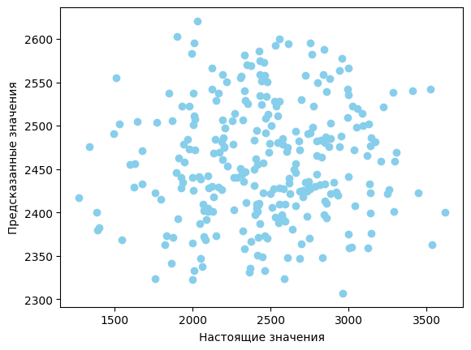

```python
# Визуализируем на диаграмме рассеяния соотношение предсказанных и настоящих значений
y_pred_proch = lasso_regressor.predict(X_test_proch)
plt.scatter(y_test_proch, y_pred_proch, color="skyblue")
plt.xlabel("Настоящие значения")
plt.ylabel("Предсказанные значения")
plt.show()
```

```python
# Выводим значения метрик
print("Корень из среднеквадратичной ошибки:", np.sqrt(metrics.mean_squared_error(y_test_proch, y_pred_proch)))
print("MAE:", metrics.mean_absolute_error(y_test_proch, y_pred_proch))
print("R2", metrics.r2_score(y_test_proch, y_pred_proch))
print("MAPE:", metrics.mean_absolute_percentage_error(y_test_proch, y_pred_proch))

# Переносим полученные метрики в датафрейм, который будет использоваться при итоговом сравнении моделей
data_sravn = [
    [np.sqrt(metrics.mean_squared_error(y_test_proch, y_pred_proch))],
    [metrics.mean_absolute_error(y_test_proch, y_pred_proch)],
    [metrics.r2_score(y_test_proch, y_pred_proch)],
    [metrics.mean_absolute_percentage_error(y_test_proch, y_pred_proch)],
]

df_sravnenie["Lasso_proch"] = np.array(data_sravn)
```

```
Корень из среднеквадратичной ошибки: 451.3393469595164
MAE: 365.0278829816321
R2 -0.003952521344521731
MAPE: 0.15986395083226296
```

Построение и тестирование модели Лассо-регрессии (Lasso) для предсказания переменной "Модуль упругости при растяжении, ГПа"

```python
# Для построения модели используем библиотеку sklearn
lasso_regressor = Lasso(alpha=0.001)
lasso_regressor.fit(X_train_mod_uprug, y_train_mod_uprug)
```

```
Lasso(alpha=0.001)
```

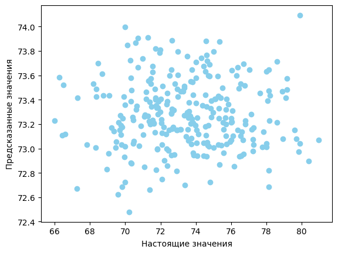

```python
# Визуализируем на диаграмме рассеяния соотношение предсказанных и настоящих значений
y_pred_mod_uprug = lasso_regressor.predict(X_test_mod_uprug)
plt.scatter(y_test_mod_uprug, y_pred_mod_uprug, color="skyblue")
plt.xlabel("Настоящие значения")
plt.ylabel("Предсказанные значения")
plt.show()
```

```python
# Выводим значения метрик
print("Корень из среднеквадратичной ошибки:", np.sqrt(metrics.mean_squared_error(y_test_mod_uprug, y_pred_mod_uprug)))
print("MAE:", metrics.mean_absolute_error(y_test_mod_uprug, y_pred_mod_uprug))
print("R2", metrics.r2_score(y_test_mod_uprug, y_pred_mod_uprug))
print("MAPE:", metrics.mean_absolute_percentage_error(y_test_mod_uprug, y_pred_mod_uprug))

# Переносим полученные метрики в датафрейм, который будет использоваться при итоговом сравнении моделей
data_sravn = [
    [np.sqrt(metrics.mean_squared_error(y_test_mod_uprug, y_pred_mod_uprug))],
    [metrics.mean_absolute_error(y_test_mod_uprug, y_pred_mod_uprug)],
    [metrics.r2_score(y_test_mod_uprug, y_pred_mod_uprug)],
    [metrics.mean_absolute_percentage_error(y_test_mod_uprug, y_pred_mod_uprug)],
]

df_sravnenie["Lasso_upr"] = np.array(data_sravn)
```

```
Корень из среднеквадратичной ошибки: 2.984351229664753
MAE: 2.421021489179655
R2 -0.0103548385744614
MAPE: 0.032975563340768836
```

**Сравнение моделей**

Выводим датафрейм, в который сохранялись значения метрик и для удобства построения диаграмм транспонируем его.

```python
df_sravnenie = df_sravnenie.transpose()
```

```python
df_sravnenie
```

|  | RMSE | MAE | R2 | MAPE |
| --- | --- | --- | --- | --- |
| LinearRegression_proch | 451.342041 | 365.029937 | -0.003965 | 0.159865 |
| LinearRegression_uprug | 2.986901 | 2.421378 | -0.012082 | 0.032981 |
| KNR_GSCV_proch | 452.453133 | 365.860100 | -0.008914 | 0.160846 |
| KNR_GSCV_upr | 2.982421 | 2.434199 | -0.009048 | 0.033143 |
| RFR_GSCV_proch | 449.623872 | 365.954796 | 0.003665 | 0.160283 |
| RFR_GSCV_upr | 2.988808 | 2.426734 | -0.013374 | 0.033051 |
| BayesR_proch | 450.450401 | 361.279222 | -0.000002 | 0.158812 |
| BayesR_upr | 2.971975 | 2.416087 | -0.001993 | 0.032909 |
| Lasso_proch | 451.339347 | 365.027883 | -0.003953 | 0.159864 |
| Lasso_upr | 2.984351 | 2.421021 | -0.010355 | 0.032976 |

Сравнение моделей. Метрика - "Корень из среднеквадратичной ошибки (RMSE)"

[output not shown]

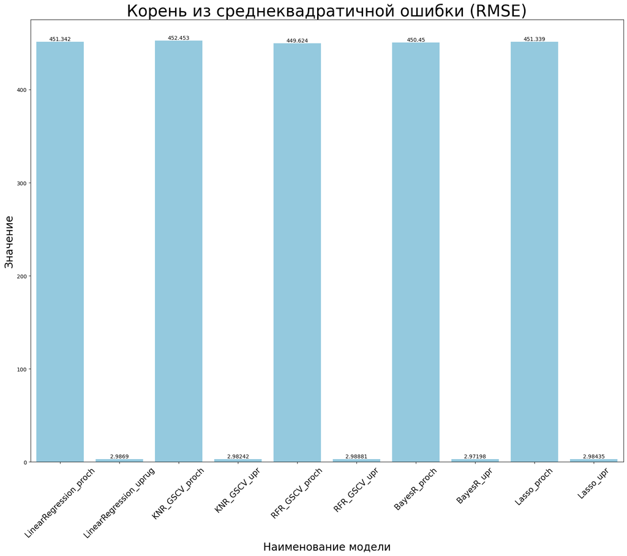

```python
plt.figure(figsize=(20,15))
ax = sns.barplot(df_sravnenie["RMSE"], color="skyblue")
plt.title("Корень из среднеквадратичной ошибки (RMSE)", fontsize=30)
plt.ylabel("Значение", fontsize=20)
plt.xlabel("Наименование модели", fontsize=20)
plt.xticks(rotation=45, fontsize=15)
ax.bar_label(ax.containers[0], fontsize=10)
```

Сравнение моделей. Метрика - "Cредняя абсолютная величина ошибка (MAE)"

[output not shown]

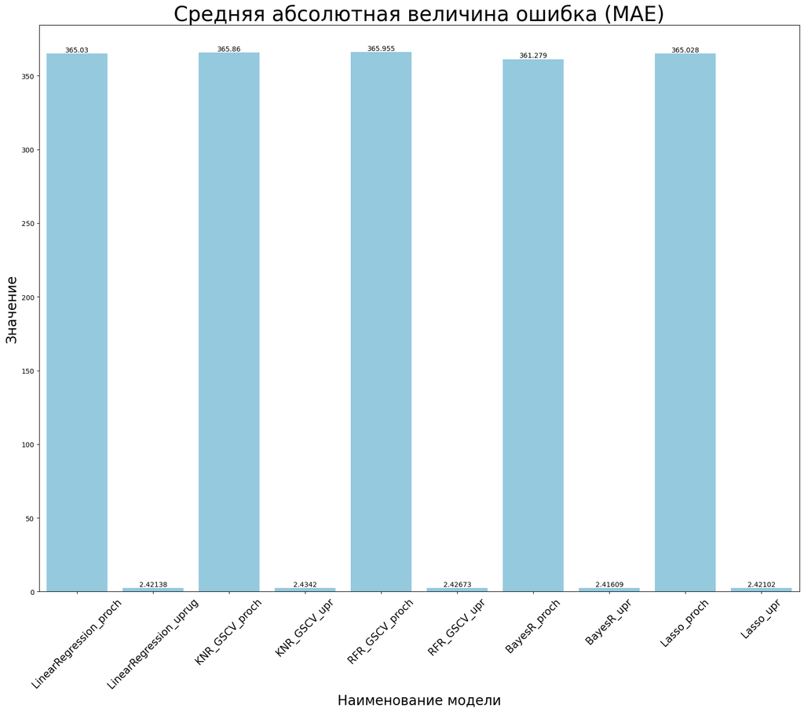

```python
plt.figure(figsize=(20, 15))
ax = sns.barplot(df_sravnenie["MAE"], color="skyblue")
plt.title("Cредняя абсолютная величина ошибка (MAE)", fontsize=30)
plt.ylabel("Значение", fontsize=20)
plt.xlabel("Наименование модели", fontsize=20)
plt.xticks(rotation=45, fontsize=15)
ax.bar_label(ax.containers[0], fontsize=10)
```

Сравнение моделей. Метрика - "Коэффициент детерминации (R2)"

[output not shown]

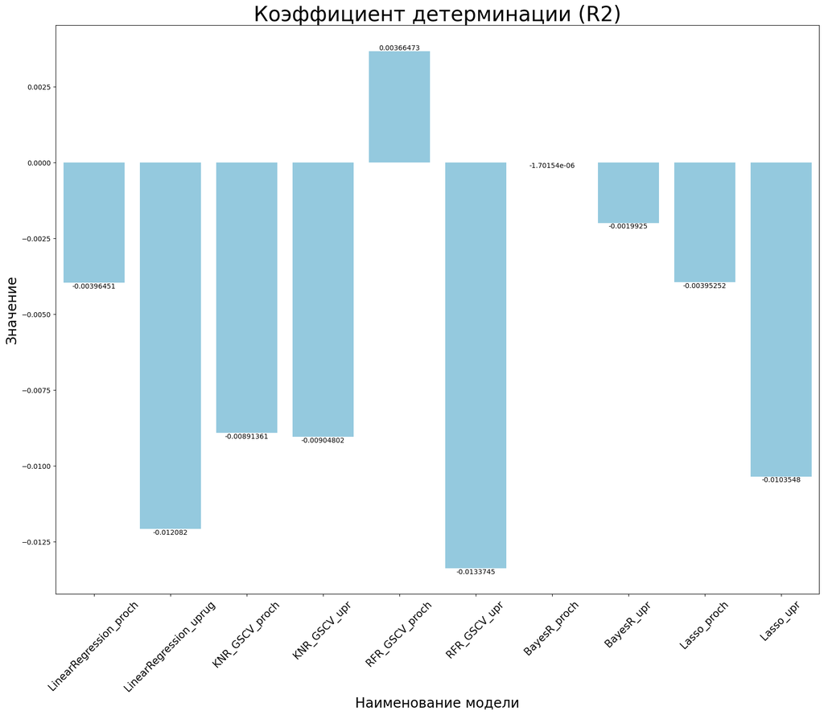

```python
plt.figure(figsize=(20, 15))
ax = sns.barplot(df_sravnenie["R2"], color="skyblue")
plt.title("Коэффициент детерминации (R2)", fontsize=30)
plt.ylabel("Значение", fontsize=20)
plt.xlabel("Наименование модели", fontsize=20)
plt.xticks(rotation=45, fontsize=15)
ax.bar_label(ax.containers[0], fontsize=10)
```

Сравнение моделей. Метрика - "Средняя абсолютная ошибка (MAPE)"

[output not shown]

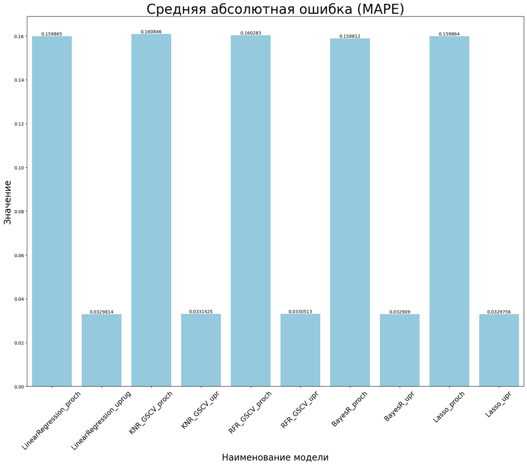

```python
plt.figure(figsize=(20, 15))
ax = sns.barplot(df_sravnenie["MAPE"], color="skyblue")
plt.title("Cредняя абсолютная ошибка (MAPE)", fontsize=30)
plt.ylabel("Значение", fontsize=20)
plt.xlabel("Наименование модели", fontsize=20)
plt.xticks(rotation=45, fontsize=15)
ax.bar_label(ax.containers[0], fontsize=10)
```

Дополнительный тест прогноза

Дополнительно проверим работу Лассо регрессора. Возьмем данные из 308 строки нашего датафрейма (которая в последствии попали в тестовую выборку)

```python
df[308:309]
```

|  | Соотношение матрица-наполнитель | Плотность, кг/м3 | модуль упругости, ГПа | Количество отвердителя, м.% | Поверхностная плотность, г/м2 | Модуль упругости при растяжении, ГПа | Прочность при растяжении, МПа | Шаг нашивки | Плотность нашивки | Угол нашивки, град_0 | Угол нашивки, град_90 | Содержание эпоксидных групп, г | Потребление смолы, г/м2 без ЭГ |
| --- | --- | --- | --- | --- | --- | --- | --- | --- | --- | --- | --- | --- | --- |
| 308 | 2.124424 | 1970.726352 | 546.816051 | 167.744937 | 351.029659 | 74.445891 | 2723.281123 | 4.894335 | 42.220404 | 1 | 0 | 52.057788 | 204.054293 |

```python
# Вводим нормализованные данные из строки 308 тестового датасета
x = [[0.33084,	0.493907,	0.334887,	0.901624,	0.271493,	0.561482,	0.354639,	0.236418,	1.0,	0.0,	0.541704,	0.655402]]
# прогнорзируем значение "Модуля упругости при растяжении, ГПа"
print(lasso_regressor.predict(x))
```

```
[73.07251385]
```

```python
# Вводим не нормализованные из строки 308 тестового датасета
g =[[2.124424,	1970.726352,	546.816051,	167.744937,	351.029659,	2723.281123,	4.894335,	42.220404,	1,	0,	52.057788,	204.054293]]
# прогнорзируем значение "Модуля упругости при растяжении, ГПа"
print(lasso_regressor.predict(g))
```

```
[-2565.92324078]
```

Передача Лассо регрессору не нормализованных данных ведет к некорректному прогнозу, т.к. модель обучалась на нормализованных данных.

**Вывод**

На основании сравнения можем сделать вывод о том, что в целом все использованные модели машинного обучения дали приблизительно равный результат. Ни одна из моделей не дала достаточно точного проноза для того, чтобы ее можно было рекомендовать к применению. Коэффициент детерминации R2 у всех моделей близок к 0 и указывает что связь между переменными регрессионной модели отсутствует, и вместо нее для оценки значения выходной переменной можно использовать простое среднее ее наблюдаемых значений. Ввиду приблизительно равных прогнозтических значений можно рекомендовать использование Линейной регрессии (т.к. метод более простой, легкий и максимально понятно интерпритируем) либо среднего арифметического значения.

Можно отметить, что на результаты прогнозной способности моделей могли повлиять:

- отсутствие линейной связи / корреляции между переменными (что было выявлено на этапе исследования данных);
- отсутствие нормального распределения у отдельных переменных;
- измерение переменных в разных единицах (проценты, г/м3, м.%, С_2, %_2, г/м2, ГПа, МПа);
- отсутствие четкого понимания как происходил сбор данных и какие переменные могут быть производными или соотноситься между собой;
- не все переменные достаточно объяснены и замерены (например, угол нашивки);
- кроме того, необходимо учитывать, что композитные материалы являются сложными материалами и в результате объединения компонентов их свойства могут изменяться существенным образом.

Таким образом, в целом необходимо проработать и более детально проанализировать датасет, получить обратную связь о том, как были собраны данные, получить экспертное мнение о том, как фактически связаны между собой отдельные переменные (возможно требуется их группировка, изменение единиц измерения).

**Дополнительное исследование от 05.07.2025**

При повторном рассмотрении итогового датасета было обнаружено, что первые 37 строк датасета существенно отличаются от остальных. В частности многие их значения выражены в виде целых чисел, а иные значения представлены в виде чисел с плавающей точкой. Поэтому делаю предположение, что эти данные могли быть синтезированы (созданы искусственно). С целью проверки данной гипотезы проведем краткое исследование.

```python
dop_df = pd.read_excel('db_itog_bez_norm.xlsx')
```

```python
dop_df.drop('Unnamed: 0', axis=1,inplace=True)
```

```python
dop_df.iloc[0:38]
```

|  | Соотношение матрица-наполнитель | Плотность, кг/м3 | модуль упругости, ГПа | Количество отвердителя, м.% | Поверхностная плотность, г/м2 | Модуль упругости при растяжении, ГПа | Прочность при растяжении, МПа | Шаг нашивки | Плотность нашивки | Угол нашивки, град_0 | Угол нашивки, град_90 | Содержание эпоксидных групп, г | Потребление смолы, г/м2 без ЭГ |
| --- | --- | --- | --- | --- | --- | --- | --- | --- | --- | --- | --- | --- | --- |
| 0 | 1.857143 | 2030.000000 | 738.736842 | 50.000000 | 210.000000 | 70.000000 | 3000.000000 | 4.000000 | 60.000000 | 1 | 0 | 52.250000 | 167.750000 |
| 1 | 1.857143 | 2030.000000 | 738.736842 | 49.900000 | 210.000000 | 70.000000 | 3000.000000 | 4.000000 | 70.000000 | 1 | 0 | 72.600000 | 147.400000 |
| 2 | 1.857143 | 2030.000000 | 738.736842 | 129.000000 | 210.000000 | 70.000000 | 3000.000000 | 5.000000 | 47.000000 | 1 | 0 | 46.750000 | 173.250000 |
| 3 | 2.771331 | 2030.000000 | 753.000000 | 111.860000 | 210.000000 | 70.000000 | 3000.000000 | 5.000000 | 57.000000 | 1 | 0 | 48.989286 | 171.010714 |
| 4 | 2.767918 | 2000.000000 | 748.000000 | 111.860000 | 210.000000 | 70.000000 | 3000.000000 | 5.000000 | 60.000000 | 1 | 0 | 48.989286 | 171.010714 |
| 5 | 2.569620 | 1910.000000 | 807.000000 | 111.860000 | 210.000000 | 70.000000 | 3000.000000 | 5.000000 | 70.000000 | 1 | 0 | 48.989286 | 171.010714 |
| 6 | 2.561475 | 1900.000000 | 535.000000 | 111.860000 | 380.000000 | 75.000000 | 1800.000000 | 7.000000 | 47.000000 | 1 | 0 | 26.721429 | 93.278571 |
| 7 | 3.557018 | 1930.000000 | 889.000000 | 129.000000 | 380.000000 | 75.000000 | 1800.000000 | 7.000000 | 57.000000 | 1 | 0 | 25.500000 | 94.500000 |
| 8 | 3.532338 | 2100.000000 | 1421.000000 | 129.000000 | 1010.000000 | 78.000000 | 2000.000000 | 7.000000 | 60.000000 | 1 | 0 | 63.750000 | 236.250000 |
| 9 | 2.919678 | 2160.000000 | 933.000000 | 129.000000 | 1010.000000 | 78.000000 | 2000.000000 | 7.000000 | 70.000000 | 1 | 0 | 63.750000 | 236.250000 |
| 10 | 2.877358 | 1990.000000 | 1628.000000 | 129.000000 | 1010.000000 | 78.000000 | 2000.000000 | 9.000000 | 47.000000 | 1 | 0 | 63.750000 | 236.250000 |
| 11 | 1.598174 | 1950.000000 | 827.000000 | 129.000000 | 470.000000 | 73.333333 | 2455.555556 | 9.000000 | 57.000000 | 1 | 0 | 46.750000 | 173.250000 |
| 12 | 2.919678 | 1980.000000 | 568.000000 | 129.000000 | 470.000000 | 73.333333 | 2455.555556 | 9.000000 | 60.000000 | 1 | 0 | 46.750000 | 173.250000 |
| 13 | 4.029126 | 1910.000000 | 800.000000 | 129.000000 | 470.000000 | 73.333333 | 2455.555556 | 9.000000 | 70.000000 | 1 | 0 | 46.750000 | 173.250000 |
| 14 | 2.934783 | 2030.000000 | 302.000000 | 129.000000 | 210.000000 | 70.000000 | 3000.000000 | 10.000000 | 47.000000 | 1 | 0 | 46.750000 | 173.250000 |
| 15 | 3.557018 | 1880.000000 | 313.000000 | 129.000000 | 210.000000 | 70.000000 | 3000.000000 | 10.000000 | 57.000000 | 1 | 0 | 46.750000 | 173.250000 |
| 16 | 4.193548 | 1950.000000 | 506.000000 | 129.000000 | 380.000000 | 75.000000 | 1800.000000 | 10.000000 | 60.000000 | 1 | 0 | 25.500000 | 94.500000 |
| 17 | 4.897959 | 1890.000000 | 540.000000 | 129.000000 | 380.000000 | 75.000000 | 1800.000000 | 10.000000 | 70.000000 | 1 | 0 | 25.500000 | 94.500000 |
| 18 | 2.877358 | 2000.000000 | 205.000000 | 111.860000 | 1010.000000 | 78.000000 | 2000.000000 | 4.000000 | 47.000000 | 0 | 1 | 66.803571 | 233.196429 |
| 19 | 1.598174 | 1920.000000 | 456.000000 | 111.860000 | 470.000000 | 73.333333 | 2455.555556 | 4.000000 | 57.000000 | 0 | 1 | 48.989286 | 171.010714 |
| 20 | 4.029126 | 1880.000000 | 622.000000 | 111.860000 | 470.000000 | 73.333333 | 2455.555556 | 4.000000 | 60.000000 | 0 | 1 | 48.989286 | 171.010714 |
| 21 | 2.587348 | 1953.274926 | 1136.596135 | 137.627420 | 555.893453 | 80.803222 | 2587.342983 | 4.000000 | 70.000000 | 0 | 1 | 55.104551 | 191.508566 |
| 22 | 2.046471 | 2037.631811 | 707.570887 | 101.617251 | 547.601219 | 73.817067 | 2624.026407 | 5.000000 | 57.000000 | 0 | 1 | 41.246538 | 136.952018 |
| 23 | 1.856476 | 2018.220332 | 836.294382 | 135.401697 | 150.961449 | 77.210762 | 2473.187195 | 5.000000 | 60.000000 | 0 | 1 | 32.606770 | 90.737792 |
| 24 | 3.305535 | 1917.907506 | 478.286247 | 105.786930 | 526.692159 | 72.345709 | 3059.032991 | 5.000000 | 70.000000 | 0 | 1 | 49.256708 | 226.319171 |
| 25 | 2.709554 | 1892.071124 | 641.052549 | 96.563293 | 804.592621 | 74.511359 | 2288.967377 | 7.000000 | 47.000000 | 0 | 1 | 29.154177 | 97.662162 |
| 26 | 2.282825 | 2008.357592 | 393.967325 | 149.372832 | 535.371459 | 72.244924 | 2704.445081 | 7.000000 | 57.000000 | 0 | 1 | 56.553864 | 204.523207 |
| 27 | 1.978140 | 1973.629097 | 991.724095 | 149.372128 | 485.453778 | 75.665701 | 2448.943079 | 7.000000 | 60.000000 | 0 | 1 | 32.093444 | 130.400250 |
| 28 | 1.771436 | 1872.491560 | 801.033883 | 79.794548 | 864.929184 | 70.947592 | 2796.785402 | 7.000000 | 70.000000 | 0 | 1 | 27.503887 | 95.852377 |
| 29 | 3.277087 | 2010.047012 | 339.550423 | 67.498993 | 117.535234 | 67.478707 | 2462.605386 | 9.000000 | 47.000000 | 0 | 1 | 50.265372 | 156.753209 |
| 30 | 2.984362 | 1912.315437 | 1183.091845 | 133.549001 | 377.389009 | 75.290452 | 2303.770656 | 9.000000 | 57.000000 | 0 | 1 | 46.662581 | 153.917668 |
| 31 | 2.916150 | 1879.969846 | 1003.270178 | 109.239530 | 408.354239 | 71.700856 | 3086.546196 | 9.000000 | 60.000000 | 0 | 1 | 49.359994 | 142.831168 |
| 32 | 3.247617 | 1813.234600 | 757.874479 | 81.379871 | 575.062857 | 69.341133 | 3188.136358 | 9.000000 | 70.000000 | 0 | 1 | 59.228521 | 193.642048 |
| 33 | 2.423876 | 1908.940601 | 530.228686 | 58.262414 | 456.908047 | 74.244354 | 1890.505807 | 10.000000 | 47.000000 | 0 | 1 | 53.611671 | 169.087817 |
| 34 | 5.098993 | 1977.339047 | 1572.096042 | 132.343060 | 690.364836 | 72.341640 | 1386.578973 | 10.000000 | 57.000000 | 0 | 1 | 69.054800 | 202.846594 |
| 35 | 2.444177 | 2085.495837 | 931.310636 | 110.564840 | 278.230020 | 71.479060 | 2740.229631 | 10.000000 | 60.000000 | 0 | 1 | 44.123263 | 143.738110 |
| 36 | 2.667697 | 2078.894676 | 1542.168458 | 132.147403 | 787.299217 | 76.471788 | 2559.643047 | 10.000000 | 70.000000 | 0 | 1 | 37.124158 | 126.778620 |
| 37 | 3.034399 | 1968.401388 | 455.871019 | 61.421297 | 637.376893 | 75.090372 | 2848.490078 | 7.856167 | 64.301964 | 1 | 0 | 73.068457 | 237.983941 |

Исключаем искуственные столбцы.

```python
list = range(0,37,1)
dop_df.drop([*list], inplace=True)
```

```python
dop_df.head()
```

|  | Соотношение матрица-наполнитель | Плотность, кг/м3 | модуль упругости, ГПа | Количество отвердителя, м.% | Поверхностная плотность, г/м2 | Модуль упругости при растяжении, ГПа | Прочность при растяжении, МПа | Шаг нашивки | Плотность нашивки | Угол нашивки, град_0 | Угол нашивки, град_90 | Содержание эпоксидных групп, г | Потребление смолы, г/м2 без ЭГ |
| --- | --- | --- | --- | --- | --- | --- | --- | --- | --- | --- | --- | --- | --- |
| 37 | 3.034399 | 1968.401388 | 455.871019 | 61.421297 | 637.376893 | 75.090372 | 2848.490078 | 7.856167 | 64.301964 | 1 | 0 | 73.068457 | 237.983941 |
| 38 | 2.664389 | 1996.159145 | 525.057774 | 77.506883 | 28.658102 | 69.489773 | 2220.587445 | 6.675780 | 78.623299 | 1 | 0 | 57.056756 | 257.719913 |
| 39 | 1.193530 | 1965.929227 | 899.603701 | 102.959069 | 871.088955 | 73.454695 | 2335.541792 | 7.526398 | 38.176975 | 1 | 0 | 17.815035 | 73.232612 |
| 40 | 2.914333 | 2049.373404 | 382.263359 | 81.352047 | 561.992131 | 69.814615 | 2262.784366 | 8.325699 | 46.045428 | 1 | 0 | 49.678900 | 253.396553 |
| 41 | 4.315666 | 1913.379677 | 822.918735 | 143.576937 | 260.859341 | 75.957329 | 1639.912525 | 7.656211 | 33.571024 | 1 | 0 | 60.262771 | 187.981559 |

```python
dop_df.shape
```

```
(888, 13)
```

Подготавливаем датафреймы

```python
Xd_proch = dop_df.drop("Прочность при растяжении, МПа", axis=1)
yd_proch = dop_df['Прочность при растяжении, МПа']

Xd_mod_uprug = dop_df.drop("Модуль упругости при растяжении, ГПа", axis=1)
yd_mod_uprug = dop_df["Модуль упругости при растяжении, ГПа"]
```

Нормализация

```python
mms_dproch = MinMaxScaler()
col = Xd_proch.columns
result = mms_dproch.fit_transform(Xd_proch)

Xd_proch = pd.DataFrame(result, columns = col)
Xd_proch.describe()
```

|  | Соотношение матрица-наполнитель | Плотность, кг/м3 | модуль упругости, ГПа | Количество отвердителя, м.% | Поверхностная плотность, г/м2 | Модуль упругости при растяжении, ГПа | Шаг нашивки | Плотность нашивки | Угол нашивки, град_0 | Угол нашивки, град_90 | Содержание эпоксидных групп, г | Потребление смолы, г/м2 без ЭГ |
| --- | --- | --- | --- | --- | --- | --- | --- | --- | --- | --- | --- | --- |
| count | 888.000000 | 888.000000 | 888.000000 | 888.000000 | 888.000000 | 888.000000 | 888.000000 | 888.000000 | 888.000000 | 888.000000 | 888.000000 | 888.000000 |
| mean | 0.498170 | 0.504063 | 0.453269 | 0.505054 | 0.374192 | 0.487271 | 0.501530 | 0.502884 | 0.486486 | 0.513514 | 0.487567 | 0.506469 |
| std | 0.188600 | 0.188239 | 0.202600 | 0.187826 | 0.216893 | 0.195308 | 0.184373 | 0.194733 | 0.500099 | 0.500099 | 0.190908 | 0.190361 |
| min | 0.000000 | 0.000000 | 0.000000 | 0.000000 | 0.000000 | 0.000000 | 0.000000 | 0.000000 | 0.000000 | 0.000000 | 0.000000 | 0.000000 |
| 25% | 0.370991 | 0.370092 | 0.306972 | 0.376190 | 0.206504 | 0.357440 | 0.373371 | 0.376780 | 0.000000 | 0.000000 | 0.347834 | 0.380550 |
| 50% | 0.494913 | 0.511692 | 0.453027 | 0.501726 | 0.356181 | 0.480836 | 0.502075 | 0.504310 | 0.000000 | 1.000000 | 0.486314 | 0.503554 |
| 75% | 0.629517 | 0.625981 | 0.591871 | 0.640147 | 0.538857 | 0.617610 | 0.622800 | 0.630352 | 1.000000 | 1.000000 | 0.618045 | 0.640242 |
| max | 1.000000 | 1.000000 | 1.000000 | 1.000000 | 1.000000 | 1.000000 | 1.000000 | 1.000000 | 1.000000 | 1.000000 | 1.000000 | 1.000000 |

```python
mms_dmod_uprug = MinMaxScaler()
col = Xd_mod_uprug.columns
result = mms_dmod_uprug.fit_transform(Xd_mod_uprug)

Xd_mod_uprug = pd.DataFrame(result, columns = col)
Xd_mod_uprug.describe()
```

|  | Соотношение матрица-наполнитель | Плотность, кг/м3 | модуль упругости, ГПа | Количество отвердителя, м.% | Поверхностная плотность, г/м2 | Прочность при растяжении, МПа | Шаг нашивки | Плотность нашивки | Угол нашивки, град_0 | Угол нашивки, град_90 | Содержание эпоксидных групп, г | Потребление смолы, г/м2 без ЭГ |
| --- | --- | --- | --- | --- | --- | --- | --- | --- | --- | --- | --- | --- |
| count | 888.000000 | 888.000000 | 888.000000 | 888.000000 | 888.000000 | 888.000000 | 888.000000 | 888.000000 | 888.000000 | 888.000000 | 888.000000 | 888.000000 |
| mean | 0.498170 | 0.504063 | 0.453269 | 0.505054 | 0.374192 | 0.506406 | 0.501530 | 0.502884 | 0.486486 | 0.513514 | 0.487567 | 0.506469 |
| std | 0.188600 | 0.188239 | 0.202600 | 0.187826 | 0.216893 | 0.188674 | 0.184373 | 0.194733 | 0.500099 | 0.500099 | 0.190908 | 0.190361 |
| min | 0.000000 | 0.000000 | 0.000000 | 0.000000 | 0.000000 | 0.000000 | 0.000000 | 0.000000 | 0.000000 | 0.000000 | 0.000000 | 0.000000 |
| 25% | 0.370991 | 0.370092 | 0.306972 | 0.376190 | 0.206504 | 0.377215 | 0.373371 | 0.376780 | 0.000000 | 0.000000 | 0.347834 | 0.380550 |
| 50% | 0.494913 | 0.511692 | 0.453027 | 0.501726 | 0.356181 | 0.505343 | 0.502075 | 0.504310 | 0.000000 | 1.000000 | 0.486314 | 0.503554 |
| 75% | 0.629517 | 0.625981 | 0.591871 | 0.640147 | 0.538857 | 0.627759 | 0.622800 | 0.630352 | 1.000000 | 1.000000 | 0.618045 | 0.640242 |
| max | 1.000000 | 1.000000 | 1.000000 | 1.000000 | 1.000000 | 1.000000 | 1.000000 | 1.000000 | 1.000000 | 1.000000 | 1.000000 | 1.000000 |

```python
Xd_train_proch, Xd_test_proch, yd_train_proch, yd_test_proch = train_test_split(Xd_proch, yd_proch, test_size=0.3, random_state=0, shuffle=True)
```

```python
Xd_train_mod_uprug, Xd_test_mod_uprug, yd_train_mod_uprug, yd_test_mod_uprug = train_test_split(Xd_mod_uprug, yd_mod_uprug, test_size=0.3, random_state=0, shuffle=True)
```

Линейная регрессия

```python
# При построении модели пользуемся библиотекой sklearn.linear_model
regressor = LinearRegression()
regressor.fit(Xd_train_proch, yd_train_proch)
yd_pred_proch = regressor.predict(Xd_test_proch)

# Выводим значения метрик
print("Корень из среднеквадратичной ошибки:", np.sqrt(metrics.mean_squared_error(yd_test_proch, yd_pred_proch)))
print("MAE:", metrics.mean_absolute_error(yd_test_proch, yd_pred_proch))
print("R2", metrics.r2_score(yd_test_proch, yd_pred_proch))
print("MAPE:", metrics.mean_absolute_percentage_error(yd_test_proch, yd_pred_proch))
print("Коэффициенты регрессии:", regressor.coef_)
print("Константа:", regressor.intercept_)


# Создаем датафрейм в который занесем результаты тестирования каждой модели
# Данный датафрейм используем при итоговом сравнении моделей
dop_data_sravn = [
    [np.sqrt(metrics.mean_squared_error(yd_test_proch, yd_pred_proch))],
    [metrics.mean_absolute_error(yd_test_proch, yd_pred_proch)],
    [metrics.r2_score(yd_test_proch, yd_pred_proch)],
    [metrics.mean_absolute_percentage_error(yd_test_proch, yd_pred_proch)],
]

metrics_index = ['RMSE','MAE','R2','MAPE']
dop_df_sravnenie = pd.DataFrame(data=dop_data_sravn, index=metrics_index)
dop_df_sravnenie.rename(columns={0:'LinearRegression_dproch'},inplace=True)
```

```
Корень из среднеквадратичной ошибки: 465.89100157687966
MAE: 378.4267858184801
R2 -0.011597094210259229
MAPE: 0.16662095058868923
Коэффициенты регрессии: [  13.71718046 -263.65716472   18.10416732 -251.41969885   48.08560556
   -5.72416939 -124.43391044   47.19799526  -12.59643546   12.59643546
 -130.99185478   49.9816475 ]
Константа: 2771.8628811628037
```

```python
# При построении модели пользуемся библиотекой sklearn.linear_model
regressor = LinearRegression()
regressor.fit(Xd_train_mod_uprug, yd_train_mod_uprug)
yd_pred_mod_uprug = regressor.predict(Xd_test_mod_uprug)

# Выводим значения метрик
print("Корень из среднеквадратичной ошибки:", np.sqrt(metrics.mean_squared_error(yd_test_mod_uprug, yd_pred_mod_uprug)))
print("MAE:", metrics.mean_absolute_error(yd_test_mod_uprug, yd_pred_mod_uprug))
print("R2", metrics.r2_score(yd_test_mod_uprug, yd_pred_mod_uprug))
print("MAPE:", metrics.mean_absolute_percentage_error(yd_test_mod_uprug, yd_pred_mod_uprug))
print("Коэффициенты регрессии:", regressor.coef_)
print("Константа:", regressor.intercept_)

dop_data_sravn = [
    [np.sqrt(metrics.mean_squared_error(yd_test_mod_uprug, yd_pred_mod_uprug))],
    [metrics.mean_absolute_error(yd_test_mod_uprug, yd_pred_mod_uprug)],
    [metrics.r2_score(yd_test_mod_uprug, yd_pred_mod_uprug)],
    [metrics.mean_absolute_percentage_error(yd_test_mod_uprug, yd_pred_mod_uprug)],
]

dop_df_sravnenie["LinearRegression_dupr"] = np.array(dop_data_sravn)
```

```
Корень из среднеквадратичной ошибки: 3.005482159995833
MAE: 2.454921985418782
R2 -0.0220329833757702
MAPE: 0.03361677717653914
Коэффициенты регрессии: [-0.30318348 -0.02278777  0.18222356 -1.86900664  0.70899896 -0.04117522
 -0.1139297   0.26505708 -0.0629704   0.0629704   1.66253719 -0.48187011]
Константа: 73.44659197911224
```

KNeighborsRegressor

```python
knn = KNeighborsRegressor()

knn.fit(Xd_train_proch, yd_train_proch)
yd_pred_proch = knn.predict(Xd_test_proch)

# Выводим значения метрик
print("Корень из среднеквадратичной ошибки:", np.sqrt(metrics.mean_squared_error(yd_test_proch, yd_pred_proch)))
print("MAE:", metrics.mean_absolute_error(yd_test_proch, yd_pred_proch))
print("R2", metrics.r2_score(yd_test_proch, yd_pred_proch))
print("MAPE:", metrics.mean_absolute_percentage_error(yd_test_proch, yd_pred_proch))

dop_data_sravn = [
    [np.sqrt(metrics.mean_squared_error(yd_test_proch, yd_pred_proch))],
    [metrics.mean_absolute_error(yd_test_proch, yd_pred_proch)],
    [metrics.r2_score(yd_test_proch, yd_pred_proch)],
    [metrics.mean_absolute_percentage_error(yd_test_proch, yd_pred_proch)],
]

dop_df_sravnenie["KNN_dproch"] = np.array(dop_data_sravn)
```

```
Корень из среднеквадратичной ошибки: 508.5981407078656
MAE: 406.4759811484183
R2 -0.20555898669111516
MAPE: 0.17889904674604915
```

```python
# при построении модели используем библиотеку sklearn
knn = KNeighborsRegressor()

knn.fit(Xd_train_mod_uprug, yd_train_mod_uprug)
yd_pred_mod_uprug = knn.predict(Xd_test_mod_uprug)

print("Корень из среднеквадратичной ошибки:", np.sqrt(metrics.mean_squared_error(yd_test_mod_uprug, yd_pred_mod_uprug)))
print("MAE:", metrics.mean_absolute_error(yd_test_mod_uprug, yd_pred_mod_uprug))
print("R2", metrics.r2_score(yd_test_mod_uprug, yd_pred_mod_uprug))
print("MAPE:", metrics.mean_absolute_percentage_error(yd_test_mod_uprug, yd_pred_mod_uprug))

dop_data_sravn = [
    [np.sqrt(metrics.mean_squared_error(yd_test_mod_uprug, yd_pred_mod_uprug))],
    [metrics.mean_absolute_error(yd_test_mod_uprug, yd_pred_mod_uprug)],
    [metrics.r2_score(yd_test_mod_uprug, yd_pred_mod_uprug)],
    [metrics.mean_absolute_percentage_error(yd_test_mod_uprug, yd_pred_mod_uprug)],
]

dop_df_sravnenie["KNN_dupr"] = np.array(dop_data_sravn)
```

```
Корень из среднеквадратичной ошибки: 3.2812801367352455
MAE: 2.672771238948065
R2 -0.21821297816752416
MAPE: 0.03666331242314573
```

Случайный лес

```python
# строим модель регрессии RandomForestRegressor с использованием библиотеки sklearn
rfr = RandomForestRegressor(max_depth=2, random_state=0)
rfr.fit(Xd_train_proch, yd_train_proch)
yd_pred_proch = rfr.predict(Xd_test_proch)

# Выводим значения метрик
print("Корень из среднеквадратичной ошибки:", np.sqrt(metrics.mean_squared_error(yd_test_proch, yd_pred_proch)))
print("MAE:", metrics.mean_absolute_error(yd_test_proch, yd_pred_proch))
print("R2", metrics.r2_score(yd_test_proch, yd_pred_proch))
print("MAPE:", metrics.mean_absolute_percentage_error(yd_test_proch, yd_pred_proch))

dop_data_sravn = [
    [np.sqrt(metrics.mean_squared_error(yd_test_proch, yd_pred_proch))],
    [metrics.mean_absolute_error(yd_test_proch, yd_pred_proch)],
    [metrics.r2_score(yd_test_proch, yd_pred_proch)],
    [metrics.mean_absolute_percentage_error(yd_test_proch, yd_pred_proch)],
]

dop_df_sravnenie["RFR_dproch"] = np.array(dop_data_sravn)
```

```
Корень из среднеквадратичной ошибки: 464.21536261377867
MAE: 377.9401589360584
R2 -0.004333492959275764
MAPE: 0.16678429721523605
```

```python
# строим модель регрессии RandomForestRegressor с использованием библиотеки sklearn
rfr = RandomForestRegressor(max_depth=2, random_state=0)
rfr.fit(Xd_train_mod_uprug, yd_train_mod_uprug)
yd_pred_mod_uprug = rfr.predict(Xd_test_mod_uprug)

# Выводим значения метрик
print("Корень из среднеквадратичной ошибки:", np.sqrt(metrics.mean_squared_error(yd_test_mod_uprug, yd_pred_mod_uprug)))
print("MAE:", metrics.mean_absolute_error(yd_test_mod_uprug, yd_pred_mod_uprug))
print("R2", metrics.r2_score(yd_test_mod_uprug, yd_pred_mod_uprug))
print("MAPE:", metrics.mean_absolute_percentage_error(yd_test_mod_uprug, yd_pred_mod_uprug))

dop_data_sravn = [
    [np.sqrt(metrics.mean_squared_error(yd_test_mod_uprug, yd_pred_mod_uprug))],
    [metrics.mean_absolute_error(yd_test_mod_uprug, yd_pred_mod_uprug)],
    [metrics.r2_score(yd_test_mod_uprug, yd_pred_mod_uprug)],
    [metrics.mean_absolute_percentage_error(yd_test_mod_uprug, yd_pred_mod_uprug)],
]

dop_df_sravnenie["RFR_dupr"] = np.array(dop_data_sravn)
```

```
Корень из среднеквадратичной ошибки: 3.009875405663134
MAE: 2.45561371092279
R2 -0.02502306841565849
MAPE: 0.03363232206077254
```

```python
# Строим модель Байесовской гребней регрессии (BayesianRidge) с помощью библиотеки sklearn
bsr = BayesianRidge()
bsr.fit(Xd_train_proch, yd_train_proch)
yd_pred_proch = bsr.predict(Xd_test_proch)

# Выводим значения метрик
print("Корень из среднеквадратичной ошибки:", np.sqrt(metrics.mean_squared_error(yd_test_proch, yd_pred_proch)))
print("MAE:", metrics.mean_absolute_error(yd_test_proch, yd_pred_proch))
print("R2", metrics.r2_score(yd_test_proch, yd_pred_proch))
print("MAPE:", metrics.mean_absolute_percentage_error(yd_test_proch, yd_pred_proch))


dop_data_sravn = [
    [np.sqrt(metrics.mean_squared_error(yd_test_proch, yd_pred_proch))],
    [metrics.mean_absolute_error(yd_test_proch, yd_pred_proch)],
    [metrics.r2_score(yd_test_proch, yd_pred_proch)],
    [metrics.mean_absolute_percentage_error(yd_test_proch, yd_pred_proch)],
]

dop_df_sravnenie["BR_dproch"] = np.array(dop_data_sravn)
```

```
Корень из среднеквадратичной ошибки: 463.47835099767036
MAE: 376.11626491686496
R2 -0.0011469639615064864
MAPE: 0.16564304006411398
```

```python
# Строим модель Байесовской гребней регрессии (BayesianRidge) с помощью библиотеки sklearn
bsr = BayesianRidge()
bsr.fit(Xd_train_mod_uprug, yd_train_mod_uprug)
yd_pred_mod_uprug = bsr.predict(Xd_test_mod_uprug)

# Выводим значения метрик
print("Корень из среднеквадратичной ошибки:", np.sqrt(metrics.mean_squared_error(yd_test_mod_uprug, yd_pred_mod_uprug)))
print("MAE:", metrics.mean_absolute_error(yd_test_mod_uprug, yd_pred_mod_uprug))
print("R2", metrics.r2_score(yd_test_mod_uprug, yd_pred_mod_uprug))
print("MAPE:", metrics.mean_absolute_percentage_error(yd_test_mod_uprug, yd_pred_mod_uprug))

dop_data_sravn = [
    [np.sqrt(metrics.mean_squared_error(yd_test_mod_uprug, yd_pred_mod_uprug))],
    [metrics.mean_absolute_error(yd_test_mod_uprug, yd_pred_mod_uprug)],
    [metrics.r2_score(yd_test_mod_uprug, yd_pred_mod_uprug)],
    [metrics.mean_absolute_percentage_error(yd_test_mod_uprug, yd_pred_mod_uprug)],
]

dop_df_sravnenie["BR_dupr"] = np.array(dop_data_sravn)
```

```
Корень из среднеквадратичной ошибки: 2.972967065879132
MAE: 2.427031660589892
R2 -3.8682412638824104e-05
MAPE: 0.033241733087847225
```

```python
lasso_regressor = Lasso(alpha=0.001)
lasso_regressor.fit(Xd_train_proch, yd_train_proch)
yd_pred_proch = lasso_regressor.predict(Xd_test_proch)

# Выводим значения метрик
print("Корень из среднеквадратичной ошибки:", np.sqrt(metrics.mean_squared_error(yd_test_proch, yd_pred_proch)))
print("MAE:", metrics.mean_absolute_error(yd_test_proch, yd_pred_proch))
print("R2", metrics.r2_score(yd_test_proch, yd_pred_proch))
print("MAPE:", metrics.mean_absolute_percentage_error(yd_test_proch, yd_pred_proch))

dop_data_sravn = [
    [np.sqrt(metrics.mean_squared_error(yd_test_proch, yd_pred_proch))],
    [metrics.mean_absolute_error(yd_test_proch, yd_pred_proch)],
    [metrics.r2_score(yd_test_proch, yd_pred_proch)],
    [metrics.mean_absolute_percentage_error(yd_test_proch, yd_pred_proch)],
]

dop_df_sravnenie["LASSO_dproch"] = np.array(dop_data_sravn)
```

```
Корень из среднеквадратичной ошибки: 465.88999555712246
MAE: 378.42372266165194
R2 -0.01159272543919121
MAPE: 0.16661971921007115
```

```python
# Для построения модели используем библиотеку sklearn
lasso_regressor = Lasso(alpha=0.001)
lasso_regressor.fit(Xd_train_mod_uprug, yd_train_mod_uprug)
yd_pred_mod_uprug = lasso_regressor.predict(Xd_test_mod_uprug)

# Выводим значения метрик
print("Корень из среднеквадратичной ошибки:", np.sqrt(metrics.mean_squared_error(yd_test_mod_uprug, yd_pred_mod_uprug)))
print("MAE:", metrics.mean_absolute_error(yd_test_mod_uprug, yd_pred_mod_uprug))
print("R2", metrics.r2_score(yd_test_mod_uprug, yd_pred_mod_uprug))
print("MAPE:", metrics.mean_absolute_percentage_error(yd_test_mod_uprug, yd_pred_mod_uprug))


dop_data_sravn = [
    [np.sqrt(metrics.mean_squared_error(yd_test_mod_uprug, yd_pred_mod_uprug))],
    [metrics.mean_absolute_error(yd_test_mod_uprug, yd_pred_mod_uprug)],
    [metrics.r2_score(yd_test_mod_uprug, yd_pred_mod_uprug)],
    [metrics.mean_absolute_percentage_error(yd_test_mod_uprug, yd_pred_mod_uprug)],
]

dop_df_sravnenie["LASSO_dupr"] = np.array(dop_data_sravn)
```

```
Корень из среднеквадратичной ошибки: 3.0048583052335553
MAE: 2.454836401012962
R2 -0.021608735993227768
MAPE: 0.03361806320404101
```

```python
dop_df_sravnenie = df_sravnenie.transpose()
```

```python
dop_df_sravnenie
```

|  | LinearRegression_proch | LinearRegression_uprug | KNR_GSCV_proch | KNR_GSCV_upr | RFR_GSCV_proch | RFR_GSCV_upr | BayesR_proch | BayesR_upr | Lasso_proch | Lasso_upr |
| --- | --- | --- | --- | --- | --- | --- | --- | --- | --- | --- |
| RMSE | 451.342041 | 2.986901 | 452.453133 | 2.982421 | 449.623872 | 2.988808 | 450.450401 | 2.971975 | 451.339347 | 2.984351 |
| MAE | 365.029937 | 2.421378 | 365.860100 | 2.434199 | 365.954796 | 2.426734 | 361.279222 | 2.416087 | 365.027883 | 2.421021 |
| R2 | -0.003965 | -0.012082 | -0.008914 | -0.009048 | 0.003665 | -0.013374 | -0.000002 | -0.001993 | -0.003953 | -0.010355 |
| MAPE | 0.159865 | 0.032981 | 0.160846 | 0.033143 | 0.160283 | 0.033051 | 0.158812 | 0.032909 | 0.159864 | 0.032976 |

Существенного улучшения прогноза у моделей не появилось. В данном случае можно предположить, что гипотеза о том, что данные были синтезированы не верна, либо на предсказательную способность существенно повлияли изменения в данные связанные с исключением, добавлением или изменением переменных.